# Lab 10

Author

Olivia Kelly

```r
library(tidyverse)
```

## Examples

```r
grepl("cat", c("cat", "dog", "catalog"))
```

```
[1]  TRUE FALSE  TRUE
```

```r
gsub("dog", "cat", "dog and dog")
```

```
[1] "cat and cat"
```

```r
text <- c("apple", "banana", "cherry", "date")
grep("a", text, value = TRUE)  # Matches strings containing 'a'
```

```
[1] "apple"  "banana" "date"
```

```r
grep("^a", text, value = TRUE)  # Matches strings starting with 'a'
```

```
[1] "apple"
```

```r
grep("a$", text, value = TRUE)  # Matches strings ending with 'a'
```

```
[1] "banana"
```

```r
str_detect(c("apple", "banana", "cherry"), "^a")
```

```
[1]  TRUE FALSE FALSE
```

```r
str_replace("cat and dog", "dog", "mouse")
```

```
[1] "cat and mouse"
```

```r
str_replace_all("cat and dog and dog", "dog", "mouse")
```

```
[1] "cat and mouse and mouse"
```

```r
str_extract("My email is test@example.com", "[a-z0-9._%+-]+@[a-z0-9.-]+\\.[a-z]{2,}")
```

```
[1] "test@example.com"
```

```r
str_match("Name: John", "Name: (\\w+)")
```

```
     [,1]         [,2]
[1,] "Name: John" "John"
```

```r
str_split("apple,banana,cherry", ",")
```

```
[[1]]
[1] "apple"  "banana" "cherry"
```

```r
library(tidyverse)
library(babynames)
```

```r
str_view(fruit, "berry")
```

```
 [6] │ bil<berry>
 [7] │ black<berry>
[10] │ blue<berry>
[11] │ boysen<berry>
[19] │ cloud<berry>
[21] │ cran<berry>
[29] │ elder<berry>
[32] │ goji <berry>
[33] │ goose<berry>
[38] │ huckle<berry>
[50] │ mul<berry>
[70] │ rasp<berry>
[73] │ salal <berry>
[76] │ straw<berry>
```

```
#>  [6] │ bil<berry>
#>  [7] │ black<berry>
#> [10] │ blue<berry>
#> [11] │ boysen<berry>
#> [19] │ cloud<berry>
#> [21] │ cran<berry>
#> ... and 8 more
```

```r
str_view(c("a", "ab", "ae", "bd", "ea", "eab"), "a.")
```

```
[2] │ <ab>
[3] │ <ae>
[6] │ e<ab>
```

```
#> [2] │ <ab>
#> [3] │ <ae>
#> [6] │ e<ab>
```

```r
str_view(fruit, "a...e")
```

```
 [1] │ <apple>
 [7] │ bl<ackbe>rry
[48] │ mand<arine>
[51] │ nect<arine>
[62] │ pine<apple>
[64] │ pomegr<anate>
[70] │ r<aspbe>rry
[73] │ sal<al be>rry
```

```
#>  [1] │ <apple>
#>  [7] │ bl<ackbe>rry
#> [48] │ mand<arine>
#> [51] │ nect<arine>
#> [62] │ pine<apple>
#> [64] │ pomegr<anate>
#> ... and 2 more
```

```r
# ab? matches an "a", optionally followed by a "b".
str_view(c("a", "ab", "abb"), "ab?")
```

```
[1] │ <a>
[2] │ <ab>
[3] │ <ab>b
```

```
#> [1] │ <a>
#> [2] │ <ab>
#> [3] │ <ab>b
```

```r
# ab+ matches an "a", followed by at least one "b".
str_view(c("a", "ab", "abb"), "ab+")
```

```
[2] │ <ab>
[3] │ <abb>
```

```
#> [2] │ <ab>
#> [3] │ <abb>
```

```r
# ab* matches an "a", followed by any number of "b"s.
str_view(c("a", "ab", "abb"), "ab*")
```

```
[1] │ <a>
[2] │ <ab>
[3] │ <abb>
```

```
#> [1] │ <a>
#> [2] │ <ab>
#> [3] │ <abb>
```

```r
str_view(words, "[aeiou]x[aeiou]")
```

```
[284] │ <exa>ct
[285] │ <exa>mple
[288] │ <exe>rcise
[289] │ <exi>st
```

```
#> [284] │ <exa>ct
#> [285] │ <exa>mple
#> [288] │ <exe>rcise
#> [289] │ <exi>st
```

```r
str_view(words, "[^aeiou]y[^aeiou]")
```

```
[836] │ <sys>tem
[901] │ <typ>e
```

```
#> [836] │ <sys>tem
#> [901] │ <typ>e
```

```r
str_view(fruit, "apple|melon|nut")
```

```
 [1] │ <apple>
[13] │ canary <melon>
[20] │ coco<nut>
[52] │ <nut>
[62] │ pine<apple>
[72] │ rock <melon>
[80] │ water<melon>
```

```
#>  [1] │ <apple>
#> [13] │ canary <melon>
#> [20] │ coco<nut>
#> [52] │ <nut>
#> [62] │ pine<apple>
#> [72] │ rock <melon>
#> ... and 1 more
```

```r
str_view(fruit, "aa|ee|ii|oo|uu")
```

```
 [9] │ bl<oo>d orange
[33] │ g<oo>seberry
[47] │ lych<ee>
[66] │ purple mangost<ee>n
```

```
#>  [9] │ bl<oo>d orange
#> [33] │ g<oo>seberry
#> [47] │ lych<ee>
#> [66] │ purple mangost<ee>n
```

```r
str_detect(c("a", "b", "c"), "[aeiou]")
```

```
[1]  TRUE FALSE FALSE
```

```
#> [1]  TRUE FALSE FALSE
```

```r
babynames |>
  filter(str_detect(name, "x")) |>
  count(name, wt = n, sort = TRUE)
```

```
# A tibble: 974 × 2
   name            n
   <chr>       <int>
 1 Alexander  665492
 2 Alexis     399551
 3 Alex       278705
 4 Alexandra  232223
 5 Max        148787
 6 Alexa      123032
 7 Maxine     112261
 8 Alexandria  97679
 9 Maxwell     90486
10 Jaxon       71234
# ℹ 964 more rows
```

```
#> # A tibble: 974 × 2
#>   name           n
#>   <chr>      <int>
#> 1 Alexander 665492
#> 2 Alexis    399551
#> 3 Alex      278705
#> 4 Alexandra 232223
#> 5 Max       148787
#> 6 Alexa     123032
#> # ℹ 968 more rows
```

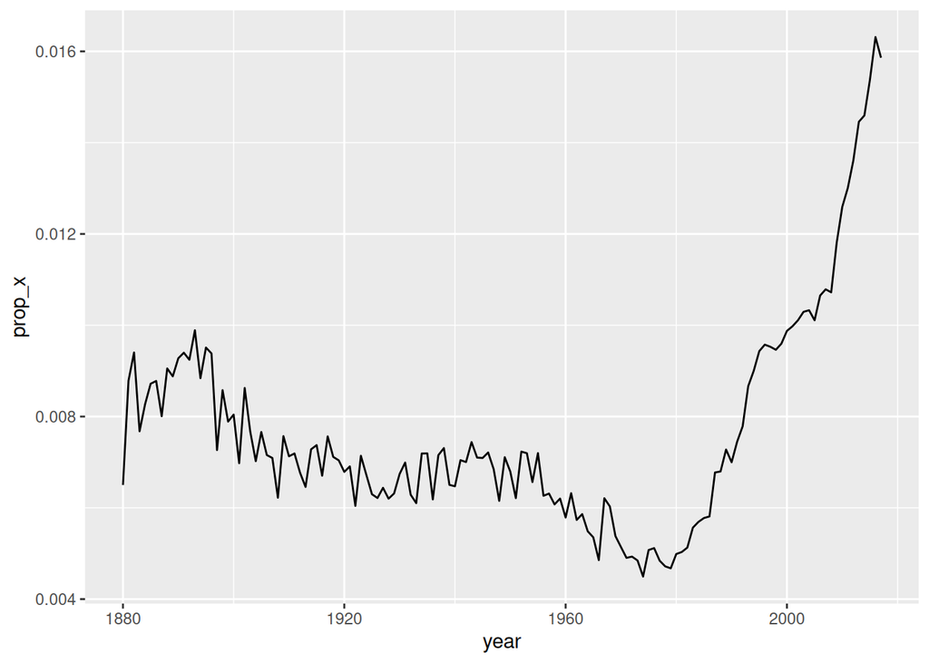

```r
babynames |>
  group_by(year) |>
  summarize(prop_x = mean(str_detect(name, "x"))) |>
  ggplot(aes(x = year, y = prop_x)) +
  geom_line()
```

```r
df <- tribble(
  ~str,
  "<Sheryl>-F_34",
  "<Kisha>-F_45",
  "<Brandon>-N_33",
  "<Sharon>-F_38",
  "<Penny>-F_58",
  "<Justin>-M_41",
  "<Patricia>-F_84",
)
```

```r
df |>
  separate_wider_regex(
    str,
    patterns = c(
      "<",
      name = "[A-Za-z]+",
      ">-",
      gender = ".",
      "_",
      age = "[0-9]+"
    )
  )
```

```
# A tibble: 7 × 3
  name     gender age
  <chr>    <chr>  <chr>
1 Sheryl   F      34
2 Kisha    F      45
3 Brandon  N      33
4 Sharon   F      38
5 Penny    F      58
6 Justin   M      41
7 Patricia F      84
```

```
#> # A tibble: 7 × 3
#>   name    gender age
#>   <chr>   <chr>  <chr>
#> 1 Sheryl  F      34
#> 2 Kisha   F      45
#> 3 Brandon N      33
#> 4 Sharon  F      38
#> 5 Penny   F      58
#> 6 Justin  M      41
#> # ℹ 1 more row
```

```r
str_detect(c("a", "b", "c"), "[aeiou]")
```

```
[1]  TRUE FALSE FALSE
```

```
#> [1]  TRUE FALSE FALSE
```

## **15.3.5** Exercises

### 1. What baby name has the most vowels? What name has the highest proportion of vowels? (Hint: what is the denominator?)

```r
library(dplyr)
library(stringr)

babynames |>
  count(name) |>
  mutate(
    vowels = str_count(name, "[aeiouAEIOU]")
  ) |>
  slice_max(vowels, n = 1)
```

```
# A tibble: 2 × 3
  name                n vowels
  <chr>           <int>  <int>
1 Mariadelrosario     3      8
2 Mariaguadalupe     37      8
```

[output not shown]

```r
library(dplyr)
library(stringr)

babynames |>
  count(name) |>
  mutate(
    total_letters = str_count(name, "[a-zA-Z]"),
    vowels = str_count(name, "[aeiouAEIOU]"),
    vowel_ratio = vowels / total_letters
  ) |>
  slice_max(vowel_ratio, n = 1)
```

```
# A tibble: 8 × 5
  name      n total_letters vowels vowel_ratio
  <chr> <int>         <int>  <int>       <dbl>
1 Ai       40             2      2           1
2 Aia       4             3      3           1
3 Aoi      24             3      3           1
4 Ea        2             2      2           1
5 Eua       4             3      3           1
6 Ia       19             2      2           1
7 Ii        1             2      2           1
8 Io       16             2      2           1
```

### 2. Replace all forward slashes in `"a/b/c/d/e"` with backslashes. What happens if you attempt to undo the transformation by replacing all backslashes with forward slashes? (We’ll discuss the problem very soon.)

```r
"a/b/c/d/e"
```

```
[1] "a/b/c/d/e"
```

### 3. Implement a simple version of [`str_to_lower()`](https://stringr.tidyverse.org/reference/case.html) using [`str_replace_all()`](https://stringr.tidyverse.org/reference/str_replace.html).

```r
library(dplyr)
library(stringr)

str_to_lower_manual <- function(x) {
  str_replace_all(x, c(
    "A" = "a", "B" = "b", "C" = "c", "D" = "d", "E" = "e",
    "F" = "f", "G" = "g", "H" = "h", "I" = "i", "J" = "j",
    "K" = "k", "L" = "l", "M" = "m", "N" = "n", "O" = "o",
    "P" = "p", "Q" = "q", "R" = "r", "S" = "s", "T" = "t",
    "U" = "u", "V" = "v", "W" = "w", "X" = "x", "Y" = "y",
    "Z" = "z"
  ))
}

babynames_lower <- babynames |>
  mutate(name = str_to_lower_manual(name))

head(babynames_lower)
```

```
# A tibble: 6 × 5
   year sex   name          n   prop
  <dbl> <chr> <chr>     <int>  <dbl>
1  1880 F     mary       7065 0.0724
2  1880 F     anna       2604 0.0267
3  1880 F     emma       2003 0.0205
4  1880 F     elizabeth  1939 0.0199
5  1880 F     minnie     1746 0.0179
6  1880 F     margaret   1578 0.0162
```

### 4. Create a regular expression that will match telephone numbers as commonly written in your country.

```r
library(stringr)

phone <- regex(
  r"(
    \(?         # optional opening parenthesis
    \d{3}       # area code (3 digits)
    \)?         # optional closing parenthesis
    [\s.-]?     # optional separator (space, dot, or dash)
    \d{3}       # first 3 digits
    [\s.-]?     # optional separator
    \d{4}       # last 4 digits
  )",
  comments = TRUE
)

str_extract(
  c("514-791-8141", "(123) 456 7890", "123456", "123.456.7890", "123 456 7890"),
  phone
)
```

```
[1] "514-791-8141"   "(123) 456 7890" NA               "123.456.7890"
[5] "123 456 7890"
```

## **15.4.7 Exercises**

### How would you match the literal string `"'\`? How about `"$^$"`?

```r
str_detect("'\\?", "'\\\\\\?")
```

```
[1] TRUE
```

```r
str_detect("$^$", "\\$\\^\\$")
```

```
[1] TRUE
```

### 2. Explain why each of these patterns don’t match a `\`: `"\"`, `"\\"`, `"\\\"`.

The first pattern doesn’t match because its is used as an escape character but there’s nothing to escape from, the second incomeplte so it doesn’t work, and the third needs to match a literal so you’ll need four backslashes.

### 3. Given the corpus of common words in [`stringr::words`](https://stringr.tidyverse.org/reference/stringr-data.html), create regular expressions that find all words that:

```r
library(stringr)
data("words", package = "stringr")
```

```r
str_subset(words, "^y")
```

```
[1] "year"      "yes"       "yesterday" "yet"       "you"       "young"
```

1. b. Don’t start with “y”.

```r
str_subset(words, "^[^y]")
```

```
  [1] "a"           "able"        "about"       "absolute"    "accept"
  [6] "account"     "achieve"     "across"      "act"         "active"
 [11] "actual"      "add"         "address"     "admit"       "advertise"
 [16] "affect"      "afford"      "after"       "afternoon"   "again"
 [21] "against"     "age"         "agent"       "ago"         "agree"
 [26] "air"         "all"         "allow"       "almost"      "along"
 [31] "already"     "alright"     "also"        "although"    "always"
 [36] "america"     "amount"      "and"         "another"     "answer"
 [41] "any"         "apart"       "apparent"    "appear"      "apply"
 [46] "appoint"     "approach"    "appropriate" "area"        "argue"
 [51] "arm"         "around"      "arrange"     "art"         "as"
 [56] "ask"         "associate"   "assume"      "at"          "attend"
 [61] "authority"   "available"   "aware"       "away"        "awful"
 [66] "baby"        "back"        "bad"         "bag"         "balance"
 [71] "ball"        "bank"        "bar"         "base"        "basis"
```

[output cut: 180 more lines]

1. c. End with “x”.

```r
str_subset(words, "x$")
```

```
[1] "box" "sex" "six" "tax"
```

1. d. Are exactly three letters long. (Don’t cheat by using [`str_length()`](https://stringr.tidyverse.org/reference/str_length.html)!)

```r
str_subset(words, "^.{3}$")
```

```
  [1] "act" "add" "age" "ago" "air" "all" "and" "any" "arm" "art" "ask" "bad"
 [13] "bag" "bar" "bed" "bet" "big" "bit" "box" "boy" "bus" "but" "buy" "can"
 [25] "car" "cat" "cup" "cut" "dad" "day" "die" "dog" "dry" "due" "eat" "egg"
 [37] "end" "eye" "far" "few" "fit" "fly" "for" "fun" "gas" "get" "god" "guy"
 [49] "hit" "hot" "how" "job" "key" "kid" "lad" "law" "lay" "leg" "let" "lie"
 [61] "lot" "low" "man" "may" "mrs" "new" "non" "not" "now" "odd" "off" "old"
 [73] "one" "out" "own" "pay" "per" "put" "red" "rid" "run" "say" "see" "set"
 [85] "sex" "she" "sir" "sit" "six" "son" "sun" "tax" "tea" "ten" "the" "tie"
 [97] "too" "top" "try" "two" "use" "war" "way" "wee" "who" "why" "win" "yes"
[109] "yet" "you"
```

1. e. Have seven letters or more.

```r
str_subset(words, "^.{7,}$")
```

```
  [1] "absolute"    "account"     "achieve"     "address"     "advertise"
  [6] "afternoon"   "against"     "already"     "alright"     "although"
 [11] "america"     "another"     "apparent"    "appoint"     "approach"
 [16] "appropriate" "arrange"     "associate"   "authority"   "available"
 [21] "balance"     "because"     "believe"     "benefit"     "between"
 [26] "brilliant"   "britain"     "brother"     "business"    "certain"
 [31] "chairman"    "character"   "Christmas"   "colleague"   "collect"
 [36] "college"     "comment"     "committee"   "community"   "company"
 [41] "compare"     "complete"    "compute"     "concern"     "condition"
 [46] "consider"    "consult"     "contact"     "continue"    "contract"
 [51] "control"     "converse"    "correct"     "council"     "country"
 [56] "current"     "decision"    "definite"    "department"  "describe"
 [61] "develop"     "difference"  "difficult"   "discuss"     "district"
 [66] "document"    "economy"     "educate"     "electric"    "encourage"
 [71] "english"     "environment" "especial"    "evening"     "evidence"
```

[output cut: 29 more lines]

1. f. Contain a vowel-consonant pair.

```r
str_subset(words, "[aeiou][^aeiou\\W]")
```

```
  [1] "able"        "about"       "absolute"    "accept"      "account"
  [6] "achieve"     "across"      "act"         "active"      "actual"
 [11] "add"         "address"     "admit"       "advertise"   "affect"
 [16] "afford"      "after"       "afternoon"   "again"       "against"
 [21] "age"         "agent"       "ago"         "agree"       "air"
 [26] "all"         "allow"       "almost"      "along"       "already"
 [31] "alright"     "also"        "although"    "always"      "america"
 [36] "amount"      "and"         "another"     "answer"      "any"
 [41] "apart"       "apparent"    "appear"      "apply"       "appoint"
 [46] "approach"    "appropriate" "area"        "argue"       "arm"
 [51] "around"      "arrange"     "art"         "as"          "ask"
 [56] "associate"   "assume"      "at"          "attend"      "authority"
 [61] "available"   "aware"       "away"        "awful"       "baby"
 [66] "back"        "bad"         "bag"         "balance"     "ball"
 [71] "bank"        "bar"         "base"        "basis"       "bear"
```

[output cut: 174 more lines]

1. g. Contain at least two vowel-consonant pairs in a row.

```r
str_subset(words, "([aeiou][^aeiou\\W]){2,}")
```

```
  [1] "absolute"    "agent"       "along"       "america"     "another"
  [6] "apart"       "apparent"    "authority"   "available"   "aware"
 [11] "away"        "balance"     "basis"       "become"      "before"
 [16] "begin"       "behind"      "benefit"     "business"    "character"
 [21] "closes"      "community"   "consider"    "cover"       "debate"
 [26] "decide"      "decision"    "definite"    "department"  "depend"
 [31] "design"      "develop"     "difference"  "difficult"   "direct"
 [36] "divide"      "document"    "during"      "economy"     "educate"
 [41] "elect"       "electric"    "eleven"      "encourage"   "environment"
 [46] "europe"      "even"        "evening"     "ever"        "every"
 [51] "evidence"    "exact"       "example"     "exercise"    "exist"
 [56] "family"      "figure"      "final"       "finance"     "finish"
 [61] "friday"      "future"      "general"     "govern"      "holiday"
 [66] "honest"      "hospital"    "however"     "identify"    "imagine"
 [71] "individual"  "interest"    "introduce"   "item"        "jesus"
```

[output cut: 19 more lines]

1. h. Only consist of repeated vowel-consonant pairs.

   ```r
   str_subset(words, "^([aeiou][^aeiou\\W])+$")
   ```

   ```
    [1] "as"       "at"       "away"     "eleven"   "even"     "ever"
    [7] "if"       "in"       "it"       "item"     "of"       "okay"
   [13] "on"       "open"     "or"       "original" "over"     "unit"
   [19] "up"       "upon"
   ```

### 4. Create 11 regular expressions that match the British or American spellings for each of the following words: airplane/aeroplane, aluminum/aluminium, analog/analogue, ass/arse, center/centre, defense/defence, donut/doughnut, gray/grey, modeling/modelling, skeptic/sceptic, summarize/summarise. Try and make the shortest possible regex!

   ```r
   test_words <- c("airplane", "aeroplane", "aluminum", "aluminium", "donut", "doughnut")
   str_subset(test_words, "a(e)?roplane")
   ```

   ```
   [1] "aeroplane"
   ```

   ```r
   library(stringr)
   library(stringr)

   test_words <- c(
     "airplane", "aeroplane",
     "aluminum", "aluminium",
     "analog", "analogue",
     "ass", "arse",
     "center", "centre",
     "defense", "defence",
     "donut", "doughnut",
     "gray", "grey",
     "modeling", "modelling",
     "skeptic", "sceptic",
     "summarize", "summarise"
   )

   patterns <- list(
     "a(ero|ir)plane",
     "alumin(i)?um",
     "analogu?e",
     "a(r)?se",
     "cent(re|er)",
     "defen[cs]e",
     "dough?nut",
     "gr[ae]y",
     "modell?ing",
     "scept?ic",
     "summari[sz]e"
   )

   results <- lapply(patterns, function(p) str_subset(test_words, p))

   names(results) <- c(
     "airplane/aeroplane",
     "aluminum/aluminium",
     "analog/analogue",
     "ass/arse",
     "center/centre",
     "defense/defence",
     "donut/doughnut",
     "gray/grey",
     "modeling/modelling",
     "skeptic/sceptic",
     "summarize/summarise"
   )

   results
   ```

   ```
   $`airplane/aeroplane`
   [1] "airplane"  "aeroplane"

   $`aluminum/aluminium`
   [1] "aluminum"  "aluminium"

   $`analog/analogue`
   [1] "analogue"

   $`ass/arse`
   [1] "arse"

   $`center/centre`
   [1] "center" "centre"

   $`defense/defence`
   [1] "defense" "defence"

   $`donut/doughnut`
   [1] "doughnut"

   $`gray/grey`
   [1] "gray" "grey"

   $`modeling/modelling`
   [1] "modeling"  "modelling"

   $`skeptic/sceptic`
   [1] "sceptic"

   $`summarize/summarise`
   [1] "summarize" "summarise"
   ```

### 5. Switch the first and last letters in `words`. Which of those strings are still `words`?

   ```r
   library(stringr)
   library(stringr)
   data("words", package = "stringr")

   swap_first_last <- function(word) {
     if (str_length(word) < 2) return(word)
     paste0(str_sub(word, -1), str_sub(word, 2, -2), str_sub(word, 1, 1))
   }

   swapped <- sapply(words, swap_first_last)

   valid <- swapped[swapped %in% words]

   changed <- valid[names(valid) != valid]

   changed
   ```

   ```
     deal   dear    dog    god   lead     no     on   read
   "lead" "read"  "god"  "dog" "deal"   "on"   "no" "dear"
   ```

### 6. Describe in words what these regular expressions match: (read carefully to see if each entry is a regular expression or a string that defines a regular expression.)

   1. `^.*$`

   It acts “” as quotes for words or just leave them empty.

   `b. "\\{.+\\}"`

   Multiple charaters like number {12345} or letters.

   `c. \d{4}-\d{2}-\d{2}`

   Date as year month day

   `d. "\\\\{4}"`

   Its four backslashes

   `e. \..\..\..`

   Its three dot separated characters like 1.2.3.

   `f. (.)\1\1`

   Its three identical charters in a row

   `g. "(..)\\1"`

It’s a repeat of quotes terms

### 7. Solve the beginner regexp crosswords at https://regexcrossword.com/challenges/beginner.

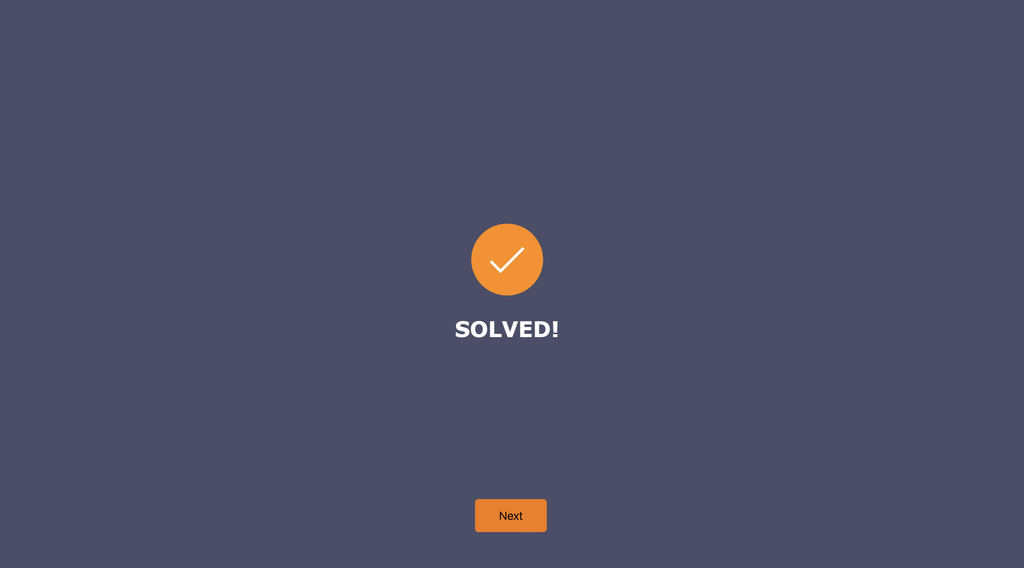

## 15.6.4 Exercise

### 1. For each of the following challenges, try solving it by using both a single regular expression, and a combination of multiple [`str_detect()`](https://stringr.tidyverse.org/reference/str_detect.html) calls.

1. 1. Find all `words` that start or end with `x`.

   ```r
   str_subset(words, "^x|x$")
   ```

   ```
   [1] "box" "sex" "six" "tax"
   ```

   b.

   ```r
   str_subset(words, "^[aeiou].*[^aeiou]$")
   ```

   ```
     [1] "about"       "accept"      "account"     "across"      "act"
     [6] "actual"      "add"         "address"     "admit"       "affect"
    [11] "afford"      "after"       "afternoon"   "again"       "against"
    [16] "agent"       "air"         "all"         "allow"       "almost"
    [21] "along"       "already"     "alright"     "although"    "always"
    [26] "amount"      "and"         "another"     "answer"      "any"
    [31] "apart"       "apparent"    "appear"      "apply"       "appoint"
    [36] "approach"    "arm"         "around"      "art"         "as"
    [41] "ask"         "at"          "attend"      "authority"   "away"
    [46] "awful"       "each"        "early"       "east"        "easy"
    [51] "eat"         "economy"     "effect"      "egg"         "eight"
    [56] "either"      "elect"       "electric"    "eleven"      "employ"
    [61] "end"         "english"     "enjoy"       "enough"      "enter"
    [66] "environment" "equal"       "especial"    "even"        "evening"
    [71] "ever"        "every"       "exact"       "except"      "exist"
    [76] "expect"      "explain"     "express"     "identify"    "if"
    [81] "important"   "in"          "indeed"      "individual"  "industry"
    [86] "inform"      "instead"     "interest"    "invest"      "it"
    [91] "item"        "obvious"     "occasion"    "odd"         "of"
    [96] "off"         "offer"       "often"       "okay"        "old"
   [101] "on"          "only"        "open"        "opportunity" "or"
   [106] "order"       "original"    "other"       "ought"       "out"
   [111] "over"        "own"         "under"       "understand"  "union"
   [116] "unit"        "university"  "unless"      "until"       "up"
   [121] "upon"        "usual"
   ```

   c. No

   ```r
   library(stringr)
   str_subset(words, "(?=.*a)(?=.*e)(?=.*i)(?=.*o)(?=.*u)")
   ```

   ```
   character(0)
   ```

### 2. Construct patterns to find evidence for and against the rule “i before e except after c”?

   ```r
   library(stringr)
   data("words", package = "stringr")

   for_rule <- str_subset(words, "(?<!c)ie")

   against_rule <- str_subset(words, "(?<!c)ei")

   exceptions <- str_subset(words, "cei")

   list(
     for_rule = head(for_rule, 10),
     against_rule = head(against_rule, 10),
     exceptions = head(exceptions, 10)
   )
   ```

   ```
   $for_rule
    [1] "achieve"    "believe"    "brief"      "client"     "die"
    [6] "experience" "field"      "friend"     "lie"        "piece"

   $against_rule
   [1] "eight"  "either" "weigh"

   $exceptions
   [1] "receive"
   ```

### 3. `colors()` contains a number of modifiers like “lightgray” and “darkblue”. How could you automatically identify these modifiers? (Think about how you might detect and then remove the colors that are modified).

   To identify these modifiers you can put them before hat color you’re using like “light” or “dark” but also with code.

   ```r
   library(stringr)

   color_names <- colors()

   modifiers <- c("light", "dark", "sky", "deep", "medium", "pale", "royal", "steel", "dodger", "slate", "misty", "peach", "lavender", "lemon", "orchid")

   modifier_pattern <- paste0("^(", paste(modifiers, collapse = "|"), ")")

   modified_colors <- str_subset(color_names, modifier_pattern)

   base_colors <- str_remove(modified_colors, modifier_pattern)

   unmodified_colors <- setdiff(color_names, modified_colors)

   list(
     modified_colors = head(modified_colors, 10),
     base_colors = head(base_colors, 10),
     unmodified_colors = head(unmodified_colors, 10)
   )
   ```

   ```
   $modified_colors
    [1] "darkblue"       "darkcyan"       "darkgoldenrod"  "darkgoldenrod1"
    [5] "darkgoldenrod2" "darkgoldenrod3" "darkgoldenrod4" "darkgray"
    [9] "darkgreen"      "darkgrey"

   $base_colors
    [1] "blue"       "cyan"       "goldenrod"  "goldenrod1" "goldenrod2"
    [6] "goldenrod3" "goldenrod4" "gray"       "green"      "grey"

   $unmodified_colors
    [1] "white"         "aliceblue"     "antiquewhite"  "antiquewhite1"
    [5] "antiquewhite2" "antiquewhite3" "antiquewhite4" "aquamarine"
    [9] "aquamarine1"   "aquamarine2"
   ```

### 4. Create a regular expression that finds any base R dataset. You can get a list of these datasets via a special use of the [`data()`](https://rdrr.io/r/utils/data.html) function: `data(package = "datasets")$results[, "Item"]`. Note that a number of old datasets are individual vectors; these contain the name of the grouping “data frame” in parentheses, so you’ll need to strip those off.

   ```r
   library(stringr)

   ds_names <- data(package = "datasets")$results[, "Item"]

   base_names <- str_extract(ds_names, "^[^(]+")

   unique(base_names)
   ```

   ```
     [1] "AirPassengers"         "BJsales"               "BJsales.lead "
     [4] "BOD"                   "CO2"                   "ChickWeight"
     [7] "DNase"                 "EuStockMarkets"        "Formaldehyde"
    [10] "HairEyeColor"          "Harman23.cor"          "Harman74.cor"
    [13] "Indometh"              "InsectSprays"          "JohnsonJohnson"
    [16] "LakeHuron"             "LifeCycleSavings"      "Loblolly"
    [19] "Nile"                  "Orange"                "OrchardSprays"
    [22] "PlantGrowth"           "Puromycin"             "Seatbelts"
    [25] "Theoph"                "Titanic"               "ToothGrowth"
    [28] "UCBAdmissions"         "UKDriverDeaths"        "UKgas"
    [31] "USAccDeaths"           "USArrests"             "USJudgeRatings"
    [34] "USPersonalExpenditure" "UScitiesD"             "VADeaths"
    [37] "WWWusage"              "WorldPhones"           "ability.cov"
    [40] "airmiles"              "airquality"            "anscombe"
    [43] "attenu"                "attitude"              "austres"
   ```

   [output cut: 21 more lines]